# Practical 2 - Estimation, hypothesis testing, and power

> **LEARNING OBJECTIVES**: In this practical you will calculate confidence intervals. You will also perform two-sample t-tests & interpret the results. And you will understand how to estimate power and sample size for differences in means.

Throughout this practical, you will be introduced to the following functions:

| Topic | Function name |
| --- | --- |
| General R | `!`, `is.na`, `round()` |
| Basic Statistics | `sum()`, `qnorm()`, `sqrt()` |
| Hypothesis testing | `t.test()` |
| Power & Sample | `power.t.test()` |

> **NOTE** This is the first vertion of this teaching material. Please contact the author to report mistakes and for general feedback at diego.aguilar-ramirez@ndph.ox.ac.uk

# 1. Set-up

## Basic descriptive statistics of the Whitehall Resurvey Study baseline data (1997)

> In this section you will get to know the Whitehall data by calculating some basic descriptive statistics. This will require you to revisit some of the commands you learned in the **Pre-course practical** and in **Practical 1**.

List of variables in Whitehall data set

| Name | Description |
| --- | --- |
| WHL1_D | Participant ID in this dataset |
| AGE | Age |
| HATTACK | Prior disease: heart attack diagnosed |
| ANGINA | Prior disease: angina diagnosed |
| STROKE | Prior disease: stroke diagnosed |
| DIAB | Prior disease: diabetes diagnosed |
| CANCER | Prior disease: cancer diagnosed |
| SBP | Systolic blood pressure |
| BMI | Body-mass index (kg/m^2) |
| CURRSMOKER | Current smoker (1=yes, 0=no) |
| HDLC | HDL cholesterol (mmol/L) |
| LDLC | LDL cholesterol (mmol/L) |
| APOB | ApoB (g/L) |
| APOA1 | ApoA1 (g/L) |
| CHOL | Total cholesterol (mmol/L) |
| CPR | C-reactive protein (mmol/l) |
| VitD | Vitamin D [25(OH)D] nmol/L |

## 1.1 Load the dataset

Be aware of where you have downloaded and saved your data file to. If you are unsure of the path, find the file, right click, hit ‘Properties’ on the menu, and then copy the file path under the heading ‘Location’. Ideally, you will have saved your data set within your **R Project folder** (see Pre-course material).

Open R and open the R Project you have been using for the course.

Let’s import the Whitehall data set.

### Classic

First, check your working directory

```r
getwd()
```

Then, use read.csv() to import the data:

```r
read.csv("path/to/my_project/data/Whitehall_like-Baseline.csv", header = T, na.strings = ".")
```

Recall that **missing data** in R appears as `NA`. `NA` is not a string or a numeric value, but an indicator of missingness. You can use the argument `na.strings` to tell `read.csv()` which strings should be interpreted as `NA`. In the Whitehall dataset, the missing indicator for continuous variables is `.`. If the argument `na.strings` is omitted, the missing values `.` will be interpreted as `characters` and then the whole column will be converted to characters.

### Using rio and here

In case you already went through the self-directed learning material and are familiar with using **rio** and **here** to import data into R, follow the next steps:

Use **here** to check your current working directory, which should be the directory of the R Project

```r
pacman::p_load(rio,here) #load the packages
here()
```

If everything looks okay, let’s import the data. If you have opened your R Project and the `Whitehall_like-Baseline.csv` file is saved in the `~/my_project/data` subfolder, then this code should work:

```r
w.hall.data <- import(here("data","Whitehall_like-Baseline.csv"), na.strings = ".")
```

Recall that **missing data** in R appears as `NA`. `NA` is not a string or a numeric value, but an indicator of missingness. You can use the argument `na.strings` to tell `import()` which strings should be interpreted as `NA`. In the Whitehall dataset, the missing indicator for continuous variables is `.`. If the argument `na.strings` is omitted, the missing values `.` will be interpreted as `characters` and then the whole column will be converted to characters.

## 1.2 Explore the data

Before doing any analyses you should always examine your data to get a feel for the data.

**Hint**: use commands from previous session > `summary()`, `dim()`, `nrow()`, `ncol()`, `names()`, `skim()`.

### Basic R

```r
str(w.hall.data)
```

```
## 'data.frame':    4327 obs. of  17 variables:
##  $ WHL1_ID   : int  10001 10002 10003 10004 10005 10006 10007 10008 10009 10010 ...
##  $ AGE       : int  77 75 82 76 73 77 71 68 71 75 ...
##  $ HATTACK   : int  0 0 0 0 0 0 0 0 0 0 ...
##  $ ANGINA    : int  0 0 0 0 0 0 0 0 0 0 ...
##  $ STROKE    : int  0 0 0 0 0 0 0 0 0 0 ...
##  $ DIAB      : int  0 0 0 0 0 0 0 0 0 0 ...
##  $ CANCER    : int  0 0 0 0 0 0 0 0 0 0 ...
##  $ SBP       : int  116 115 149 139 116 149 122 117 125 129 ...
##  $ BMI       : int  27 25 20 21 21 26 23 26 19 24 ...
##  $ CURRSMOKER: int  0 0 0 0 0 0 0 1 0 0 ...
##  $ HDLC      : num  0.67 0.97 1.19 1.58 1.81 0.77 0.98 1.15 1.11 1.26 ...
##  $ LDLC      : num  4.08 3.51 3.17 2.52 3.93 2.8 3 4.25 3.81 3.34 ...
##  $ APOB      : num  1.19 0.83 0.68 0.65 0.89 0.82 0.75 0.92 0.82 0.81 ...
##  $ APOA1     : num  0.89 0.87 0.89 0.97 1.15 0.8 0.91 0.9 0.91 1.07 ...
##  $ CHOL      : num  6.42 5.63 4.93 5.02 6.77 4.97 5.25 6.38 5.44 5.59 ...
##  $ CRP       : num  3.43 1.26 2.48 2.74 1.34 0.31 0.99 1.21 0.23 1.26 ...
##  $ VitD      : num  53.5 56.8 61.6 60.3 60.3 ...
```

```r
summary(w.hall.data)
```

```
##     WHL1_ID           AGE           HATTACK           ANGINA
##  Min.   :10001   Min.   :58.00   Min.   :0.0000   Min.   :0.0000
##  1st Qu.:11082   1st Qu.:73.00   1st Qu.:0.0000   1st Qu.:0.0000
##  Median :12164   Median :76.00   Median :0.0000   Median :0.0000
##  Mean   :12164   Mean   :76.83   Mean   :0.1123   Mean   :0.1442
##  3rd Qu.:13246   3rd Qu.:80.00   3rd Qu.:0.0000   3rd Qu.:0.0000
##  Max.   :14327   Max.   :96.00   Max.   :1.0000   Max.   :1.0000
##
##      STROKE             DIAB             CANCER            SBP
##  Min.   :0.00000   Min.   :0.00000   Min.   :0.0000   Min.   : 86.0
##  1st Qu.:0.00000   1st Qu.:0.00000   1st Qu.:0.0000   1st Qu.:119.0
##  Median :0.00000   Median :0.00000   Median :0.0000   Median :129.0
##  Mean   :0.07118   Mean   :0.06009   Mean   :0.0758   Mean   :130.8
##  3rd Qu.:0.00000   3rd Qu.:0.00000   3rd Qu.:0.0000   3rd Qu.:141.0
##  Max.   :1.00000   Max.   :1.00000   Max.   :1.0000   Max.   :230.0
##                                                       NA's   :9
##       BMI          CURRSMOKER          HDLC            LDLC
##  Min.   :15.00   Min.   :0.0000   Min.   :0.050   Min.   :1.050
##  1st Qu.:23.00   1st Qu.:0.0000   1st Qu.:0.820   1st Qu.:2.840
##  Median :25.00   Median :0.0000   Median :1.050   Median :3.350
##  Mean   :25.22   Mean   :0.1261   Mean   :1.092   Mean   :3.367
##  3rd Qu.:27.00   3rd Qu.:0.0000   3rd Qu.:1.320   3rd Qu.:3.870
##  Max.   :44.00   Max.   :1.0000   Max.   :3.070   Max.   :6.810
##  NA's   :17      NA's   :6        NA's   :25      NA's   :25
##       APOB            APOA1             CHOL            CRP
##  Min.   :0.2400   Min.   :0.5200   Min.   : 2.24   Min.   :  0.120
##  1st Qu.:0.7100   1st Qu.:0.8500   1st Qu.: 4.85   1st Qu.:  0.860
##  Median :0.8400   Median :0.9300   Median : 5.47   Median :  1.710
##  Mean   :0.8665   Mean   :0.9512   Mean   : 5.51   Mean   :  3.609
##  3rd Qu.:1.0000   3rd Qu.:1.0300   3rd Qu.: 6.15   3rd Qu.:  3.580
##  Max.   :2.4200   Max.   :2.2300   Max.   :10.77   Max.   :210.000
##  NA's   :5        NA's   :5        NA's   :5       NA's   :25
##       VitD
##  Min.   : 18.92
##  1st Qu.: 45.60
##  Median : 55.70
##  Mean   : 57.35
##  3rd Qu.: 66.69
##  Max.   :419.89
##
```

Notice how the class of some variables could be changed into factors. We will not do anything about it for this practical.

### `skimr` package

Let’s try using `skim()` from the **skimr** package:

```r
pacman::p_load(skimr)
skim(w.hall.data)
```

Data summary

| Name | w.hall.data |
| --- | --- |
| Number of rows | 4327 |
| Number of columns | 17 |
| _______________________ |  |
| Column type frequency: |  |
| numeric | 17 |
| ________________________ |  |
| Group variables | None |

**Variable type: numeric**

| skim_variable | n_missing | complete_rate | mean | sd | p0 | p25 | p50 | p75 | p100 | hist |
| --- | --- | --- | --- | --- | --- | --- | --- | --- | --- | --- |
| WHL1_ID | 0 | 1.00 | 12164.00 | 1249.24 | 10001.00 | 11082.50 | 12164.00 | 13245.50 | 14327.00 | ▇▇▇▇▇ |
| AGE | 0 | 1.00 | 76.83 | 4.86 | 58.00 | 73.00 | 76.00 | 80.00 | 96.00 | ▁▅▇▃▁ |
| HATTACK | 0 | 1.00 | 0.11 | 0.32 | 0.00 | 0.00 | 0.00 | 0.00 | 1.00 | ▇▁▁▁▁ |
| ANGINA | 0 | 1.00 | 0.14 | 0.35 | 0.00 | 0.00 | 0.00 | 0.00 | 1.00 | ▇▁▁▁▂ |
| STROKE | 0 | 1.00 | 0.07 | 0.26 | 0.00 | 0.00 | 0.00 | 0.00 | 1.00 | ▇▁▁▁▁ |
| DIAB | 0 | 1.00 | 0.06 | 0.24 | 0.00 | 0.00 | 0.00 | 0.00 | 1.00 | ▇▁▁▁▁ |
| CANCER | 0 | 1.00 | 0.08 | 0.26 | 0.00 | 0.00 | 0.00 | 0.00 | 1.00 | ▇▁▁▁▁ |
| SBP | 9 | 1.00 | 130.75 | 17.57 | 86.00 | 119.00 | 129.00 | 141.00 | 230.00 | ▂▇▂▁▁ |
| BMI | 17 | 1.00 | 25.22 | 3.26 | 15.00 | 23.00 | 25.00 | 27.00 | 44.00 | ▁▇▃▁▁ |
| CURRSMOKER | 6 | 1.00 | 0.13 | 0.33 | 0.00 | 0.00 | 0.00 | 0.00 | 1.00 | ▇▁▁▁▁ |
| HDLC | 25 | 0.99 | 1.09 | 0.38 | 0.05 | 0.82 | 1.05 | 1.32 | 3.07 | ▂▇▃▁▁ |
| LDLC | 25 | 0.99 | 3.37 | 0.78 | 1.05 | 2.84 | 3.35 | 3.87 | 6.81 | ▁▇▇▁▁ |
| APOB | 5 | 1.00 | 0.87 | 0.23 | 0.24 | 0.71 | 0.84 | 1.00 | 2.42 | ▂▇▂▁▁ |
| APOA1 | 5 | 1.00 | 0.95 | 0.14 | 0.52 | 0.85 | 0.93 | 1.03 | 2.23 | ▃▇▁▁▁ |
| CHOL | 5 | 1.00 | 5.51 | 1.01 | 2.24 | 4.85 | 5.47 | 6.15 | 10.77 | ▁▇▆▁▁ |
| CRP | 25 | 0.99 | 3.61 | 7.50 | 0.12 | 0.86 | 1.71 | 3.58 | 210.00 | ▇▁▁▁▁ |
| VitD | 0 | 1.00 | 57.35 | 17.98 | 18.92 | 45.60 | 55.70 | 66.69 | 419.89 | ▇▁▁▁▁ |

Remember: `skim()` is a simple way to quickly explore your data but it is not the only way. Moreover, `summary()`, `dim()`, `nrow()`, `ncol()`, `names()`, and other functions from **Basic R** are really helpful for running quick checks while coding and are powerful tools for analyses. Learning different ways of doing the same think might feel unnecessary, but it is actually quite handy.

Notice how the class of some variables could be changed into factors. We will not do anything about it for this practical.

# 2. Calculating standard errors and confidence intervals manually

> Here you will calculate SE and confidence intervals by hand, and interpret confidence intervals.

## 2.1 Calculating SE

In the lecture you saw that:

$$SE\ = \frac{SD}{\sqrt{n}}$$
where $SD$ is the population standard deviation, $n$ is your sample size, and $SE$ is the standard deviation of the sampling distribution.

### Question 2.1.1

**Fill in the table bellow, with answers to 3 decimal places:**

|  | APOB | APOA1 | CRP | LDLC | VitD |
| --- | --- | --- | --- | --- | --- |
| n |  |  |  |  |  |
| SD |  |  |  |  |  |
| SE |  |  |  |  |  |

**HINT**: use the following commands

To calculate $n$

```r
APOB.n <- sum(!is.na(w.hall.data$APOB)) #remember to ask R not to include missing data
APOB.n
```

To calculate $SD$

```r
APOB.sd <- sd(w.hall.data$APOB,na.rm=T) #remember to ask R to remove missing valyes
APOB.sd
round(APOB.sd,digits=3)
```

To calculate $SE$

```r
APOB.se <- APOB.sd / sqrt(APOB.n)
APOB.se
round(APOB.se,3)
```

### Answer

The resulting table should look like this:

Calculating SD and SE

|  | APOB | APOA1 | CRP | LDLC | VitD |
| --- | --- | --- | --- | --- | --- |
| n | 4322.000 | 4322.000 | 4302.000 | 4302.000 | 4327.000 |
| SD | 0.234 | 0.145 | 7.499 | 0.780 | 17.976 |
| SE | 0.004 | 0.002 | 0.114 | 0.012 | 0.273 |

## 2.2 Calculating confidence intervals

A 95% confidence interval for the sample mean is calculated using the formula:

$$[ \hat{x}-Z_{0.975}*SE,
\hat{x}+Z_{0.975}*SE ]$$

**NOTE**: $Z_{0.975}$ is the 97.5% percentile of the standard normal distribution (~1.96 SD from the mean). This can be determined more precisely using the R function `qnorm(0.975)`.

### Question 2.2.1

**Plot a histogram for the variable LDLC and determine if this variable is approximately normally distributed.**

**HINT**: Use code from previous sessions (`hist()`)

### Result 1

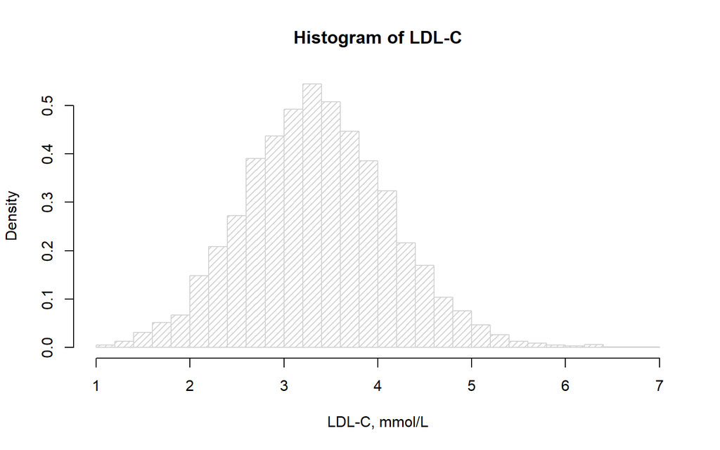

```r
hist (w.hall.data$LDLC, density=20, prob=TRUE , breaks=25, main="Histogram of LDL-C", xlab="LDL-C, mmol/L")
```

It does look like the sample distribution of LDLC is approximately normally distributed.

Let’s compare it with a normal curve:

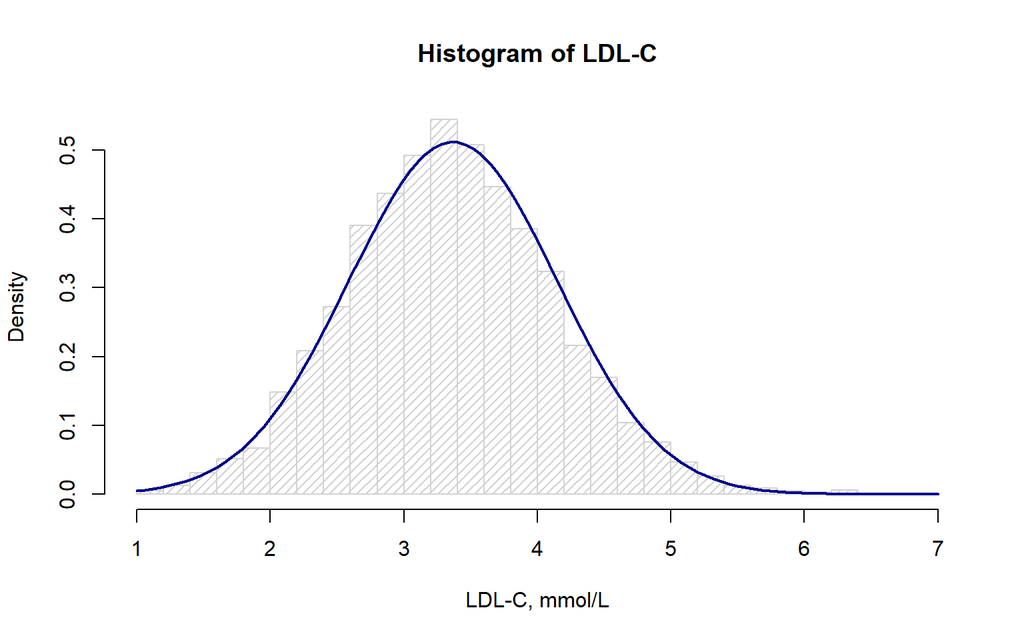

```r
# For this we will need a bit more code
hist (w.hall.data$LDLC, density=20, prob=TRUE , breaks=25, main="Histogram of LDL-C", xlab="LDL-C, mmol/L")

LDLC.mu = mean(w.hall.data$LDLC,na.rm = TRUE ) #Define sample mean
LDLC.sd = sd(w.hall.data$LDLC,na.rm = TRUE ) # Define SD

curve(dnorm(x, mean=LDLC.mu, sd=LDLC.sd) , col="darkblue" , lwd=2, add=TRUE, yaxt="n")
```

### Question 2.2.2

**Using the formula above, calculate a 95% confidence interval for the mean LDL.**

You can use a calculator (using ~1.96) and the data of the table above.

Or you can use the following code:

```r
LDLC.n    <- sum(!is.na(w.hall.data$LDLC)) # Sample size
Za        <- qnorm(0.975) # Normal distribution cut-off
ci.Z_LDLC <- c(
  LDLC.mu-(LDLC.sd/sqrt(LDLC.n)*Za), # Lower limit of CI
  LDLC.mu+(LDLC.sd/sqrt(LDLC.n)*Za)  # Upper limit of CI
  )
```

Notice how `LDLC.sd/sqrt(LDLC.n)` is effectively $\frac{SD}{\sqrt{n}}$ which is the $SE$. The implication of this is that the larger $n$ is (i.e., the sample size), the smaller $SE$ and the narrower the CI will be (i.e., there will be less uncertainty around the estimated mean).

### Result

```r
ci.Z_LDLC # Display in console
```

```
## [1] 3.344065 3.390672
```

One way of interpreting this interval is as follows: “*We are 95% confident that the true mean LDL cholesterol (for this population)* *lies between 3.344 and 3.390 mmol/L*”

# 3. Two sample t-test

> In this section you will perform a t-test and interpret the results

**NOTE**: the t-test is based on Student’s t-distribution, which is slightly different when the sample size is small (n<30).

In larger sample sizes (n>=30), the t-distribution is effectively the same as the z-distribution (Gaussian or normal distribution, which was discussed in the lecture).

You can find here more information about how $z$ and $t$ tests compare using R.

For a one-sample t-test, the syntax is:

`t.test(x, conf.level=0.95 , ...[options] )`

For a two-sample t-test, the following code should be used:

`t.test(x[group==1], x[group==2] , conf.level=0.95 , ...[options] )`

For a two-sample test, x specifies the variable on which to perform the t-test, while the group variable defines the groups to be compared. An alternative formulation for the two sample t.test is:

`t.test(x~group, data=white.data)`

See `?t.test` for details of the other options. One of the options available accounts for unequal variances across the groups, but you do not need to worry about this now.

Perform a t-test to compare the mean `LDLC` in those aged under 76 years with those aged 76 years old or more.

First, let’s recode the variable `AGE` into a binary variable `agegp`. This can be achieved by adding a new variable to the dataframe `w.hall.data`

```r
w.hall.data$agegp <- NA
w.hall.data$agegp[w.hall.data$AGE <  76] = 1
w.hall.data$agegp[w.hall.data$AGE >= 76] = 2
```

Now check the recoding worked using `table()`

```r
table(w.hall.data$agegp)
```

```
##
##    1    2
## 1837 2490
```

```r
t.test(LDLC~agegp, data=w.hall.data)
```

### Question 3.1.1

**Complete the following table and interpret the results.**

**T-test comparing `LDLC` in those aged under 76 and aged 76 or more**

| Description | Value |
| --- | --- |
| mean LDLC where age<76 (x1) |  |
| mean LDLC where age>=76 (x2) |  |
| mean difference (x1-x2) |  |
| test statistic t |  |
| 95% CI for mean difference |  |
| p-value |  |

### Result

```r
t.test(LDLC~agegp, data=w.hall.data)
```

```
##
##  Welch Two Sample t-test
##
## data:  LDLC by agegp
## t = 5.5172, df = 3994.6, p-value = 3.662e-08
## alternative hypothesis: true difference in means between group 1 and group 2 is not equal to 0
## 95 percent confidence interval:
##  0.08489092 0.17848060
## sample estimates:
## mean in group 1 mean in group 2
##        3.443160        3.311474
```

By default the test does not assume that variances of the two groups are the same and tests the null hypothesis against the **‘two-sided’** alternative that the difference in means is not equal to zero.

The output shows the test statistic (‘t’) for the test (mean of the difference/SE of the difference) and the degrees of freedom (‘df’) for the test. On the same line it also gives the p-value for the two tailed tests that hypothesise the mean difference could be in any direction. This p-value is extremely small (<0.0001) indicating strong evidence against the null hypothesis.

The 95% confidence interval for the difference in the means is also reported along with the means in each age group.

**T-test comparing `LDLC` in those aged under 76 and aged 76 or more**

| Description | Value |
| --- | --- |
| mean LDLC where age<76 (x1) | 3.44 |
| mean LDLC where age>=76 (x2) | 3.31 |
| mean difference (x1-x2) | 0.13 |
| test statistic t | 5.517 |
| 95% CI for mean difference | (0.085-0.178) |
| p-value | <0.001 |

**Interpret this result:**

- There is sufficient evidence, at 5% level, to reject the null hypothesis; OR
- There is statistically significant difference, at 5% level, between the two groups

# 4. Power and sample size

> In this section, you will practice some general commands for estimating power and sample sizes, irrespective of study design.

## 4.1 The `power` function

Calculations for power and sample size in R can be performed using the `power.test` functions. If you look at the help file, you will see that you can use these functions to compute a sample size, the power, or an effect size.

You do not need to have a data set loaded.

### Power calculations for two means

The syntax looks like this:

```r
power.t.test(n = NULL, delta = NULL, sd = 1, sig.level = 0.05,
             power = NULL,
             type = c("two.sample", "one.sample", "paired"),
             alternative = c("two.sided", "one.sided"))
```

**Arguments**

| n | Number of observations (per group) |
| --- | --- |
| delta | True difference in means |
| sd | Standard deviation |
| sig.level | Significance level (Type I error probability) |
| power | Power of test (1 minus Type II error probability) |
| type | Type of t test |
| alternative | One- or two-sided test. Can be abbreviated |

Exactly one of the parameters `n`, `delta`, `power`, `sd`, and `sig.level` must be passed as `NULL`, and that parameter is determined from the others.

See `help(power.t.test)` for more details.

You need to choose the method you are calculating a power estimate for. To do this, ask yourself if you have 1 sample, 2 independent samples or 2 paired samples? And do you want to compare means from continuous outcomes or proportions from binary/categorical outcomes (see `power.prop.test`)?

Before proceeding, remind yourself of some of the key concepts from the lecture:

#### Question 4.1.1

**What information/parameters do you need before you can estimate the sample size needed for a particular study?**

#### Answer

You need to choose a level of significance you will accept and the amount of power you want to have, i.e. the chance of detecting a difference if one exists. For two means you would need the difference in the means and the standard deviation (SD).

#### Question 4.1.2

**What information/parameters do you need before you can calculate the power of a given sample size and study?**

#### Answer

You need to determine a level of significance and the sample size for means. For two means you would need the difference in the means and the standard deviation (SD).

Using the `power.t.test` function, answer the following questions.

#### Question 4.1.3

**Estimate the sample size needed to compare the mean systolic blood pressure (SBP) in two populations.**

From a pilot study, you think that the group with lower blood pressure will have a mean SBP of 120 mm Hg, and the standard deviation (SD) of both groups will be 15 mm Hg. You have decided that you are interested in a minimum difference of 5 mm Hg, and you want 90% power, and a 5% significance level.

#### Answer

```r
power.t.test(delta=5, sd=15, sig.level=0.05, power=0.9)
```

```
##
##      Two-sample t test power calculation
##
##               n = 190.0991
##           delta = 5
##              sd = 15
##       sig.level = 0.05
##           power = 0.9
##     alternative = two.sided
##
## NOTE: n is number in *each* group
```

The estimated sample size: 382 (191 per group)

#### Question 4.1.4

**Estimate the sample size needed to compare the mean total cholesterol between two groups of men, with versus without coronary heart disease (CHD).**

Based on a previous study, you think the mean total cholesterol will be 5.5 mmol/l (SD: 1 mmol/l) amongst men without CHD, and 6.0 mmol/l (SD: 1 mmol/l) amongst men with CHD. Assume you want 90% power, and a 5% significance level.

#### Answer

```r
power.t.test(delta=0.5, sd=1, sig.level=0.05, power=0.9)
```

```
##
##      Two-sample t test power calculation
##
##               n = 85.03129
##           delta = 0.5
##              sd = 1
##       sig.level = 0.05
##           power = 0.9
##     alternative = two.sided
##
## NOTE: n is number in *each* group
```

The estimated sample size: 172 (86 per group)

#### Question 4.1.5

You have now found some other studies, looking at the same question as in question **4.1.4**, which give different estimates for the difference between the mean values of total cholesterol in the two groups, varying from 0.1 mmol/l to 1.0 mmol/l. What would be your estimated sample size if the mean total cholesterol in men with CHD is 1.0 mmol/l higher than in men without CHD? What if it was only 0.25 mmol/l higher? [Assume that your previous estimate of mean cholesterol amongst men without CHD (5.5 mmol/l) is correct].

#### Answer

Difference of 1.0 mmol/L

```r
power.t.test(delta=1, sd=1, sig.level=0.05, power=0.9)
```

```
##
##      Two-sample t test power calculation
##
##               n = 22.0211
##           delta = 1
##              sd = 1
##       sig.level = 0.05
##           power = 0.9
##     alternative = two.sided
##
## NOTE: n is number in *each* group
```

Difference of 0.25 mmol/L

```r
power.t.test(delta=0.25, sd=1, sig.level=0.05, power=0.9)
```

```
##
##      Two-sample t test power calculation
##
##               n = 337.2008
##           delta = 0.25
##              sd = 1
##       sig.level = 0.05
##           power = 0.9
##     alternative = two.sided
##
## NOTE: n is number in *each* group
```

Note how much the sample size needed changes, depending on the magnitude of the difference we expect to detect.

#### Question 4.1.6

**HINTS**:

Use a vector in order to generate a list of powers for a list of sample sizes; we can generate a list of sample sizes using the following command:

```r
samplesizes <- seq(from=50, to=500, by=50)
```

And then use this instead of a value in our `power.prop.test.`

- Use `$power` to save only the powers from the results
- Use `type ‘b’` inside your plot command in order to draw lines between the points
- `Axis` will label the axis the way you would like.

#### Answer

Define the sample sizes and calculate the power for each sample size

```r
samplesizes <- seq(from=50, to=500, by=50)
power.samplesizes <- power.t.test(n=samplesizes, delta=5, sd=15, sig.level=0.05)$power
```

Have a look at the calculated powers

```r
power.samplesizes
```

```
##  [1] 0.3784221 0.6501087 0.8205523 0.9139230 0.9607638 0.9828256 0.9927282
##  [8] 0.9970057 0.9987961 0.9995258
```

Now, let’s plot our results

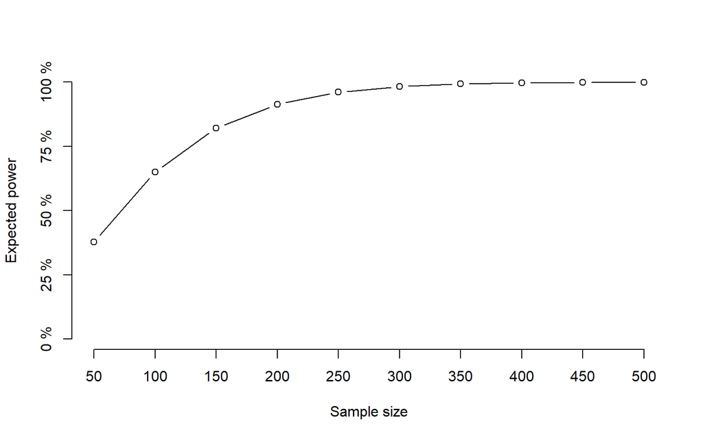

```r
plot(samplesizes, power.samplesizes,
  xlim=c(50, 500),
  xlab='Sample size',
  ylab='Expected power',
  ylim=c(0,1),
  type='b',
  axes=FALSE)

axis(1,at=samplesizes)
axis(2,at=c(0,0.25,0.5,0.75,1),labels=paste(c(0,25,50,75,100),"%"))
```

# Summary

In this practical, you:

1. Calculated confidence intervals
2. Learnt how to perform and interpret two-sample t-tests
3. Understood how to estimate power and sample size for differences in means